# Data Exploration

## Exploratory Data Analysis

Visually exploring your data is often called Exploratory Data Analysis (EDA)

- Helps you figure out what is going on.
- Gives you a clearer picture of if your data entry and analyses are correct.
- An imperative first step to data analysis.
- Allows you to feel confident with analyses.
- Not a formal process, simply whatever you like to do to examine your data.

## EDA with ggplot2

[figure not shown]

## Let’s do some EDA on our Bats Data

```r
bats <- read_csv("../data/bats.csv")
bats[1:10,]
```

```
## # A tibble: 10 x 8
##    bat_ID age   sex   condition   RFA  mass moonlight avg_temp
##     <dbl> <chr> <chr> <chr>     <dbl> <dbl>     <dbl>    <dbl>
##  1      1 A     M     NR         34.5   5         990     23.4
##  2      2 A     M     NR         41.1  11.3        77     25.4
##  3      3 A     F     L          42.9  13          77     25.4
##  4      4 A     M     NR         44.5  12          77     25.4
##  5      5 A     M     NR         35.7   8.8        85     25.0
##  6      6 A     F     L          46.6  22          85     25.0
##  7      7 A     F     L          43.9  12          77     26.5
##  8      8 A     F     L          40.2  11.5        58     26.3
##  9      9 A     F     P          33.4  10          58     26.3
## 10     10 A     F     L          44.6  13.3        58     26.3
```

## Summary Tables

```r
summary(bats)
```

```
##      bat_ID           age                sex             condition
##  Min.   :  1.00   Length:168         Length:168         Length:168
##  1st Qu.: 42.75   Class :character   Class :character   Class :character
##  Median : 84.50   Mode  :character   Mode  :character   Mode  :character
##  Mean   : 84.50
##  3rd Qu.:126.25
##  Max.   :168.00
##
##       RFA             mass         moonlight          avg_temp
##  Min.   :28.90   Min.   : 2.00   Min.   :   0.00   Min.   :17.16
##  1st Qu.:38.05   1st Qu.: 9.50   1st Qu.:   7.00   1st Qu.:22.83
##  Median :40.60   Median :11.00   Median :  50.00   Median :25.36
##  Mean   :40.49   Mean   :11.72   Mean   :  75.62   Mean   :24.34
##  3rd Qu.:42.95   3rd Qu.:13.00   3rd Qu.:  85.00   3rd Qu.:26.68
##  Max.   :51.90   Max.   :27.00   Max.   :1000.00   Max.   :28.12
##  NA's   :1
```

## Look at Your Data - Boxplots

Different variations, but the most standard recipe is:

1. Median = center line
2. Box = IQR (25th to 75th percentiles)
3. Whiskers at 1.5 X 25th and 75th percentiles
4. Dots for anything outside 1.5 X 25th and 75th percentiles

## Look at Your Data - Boxplots

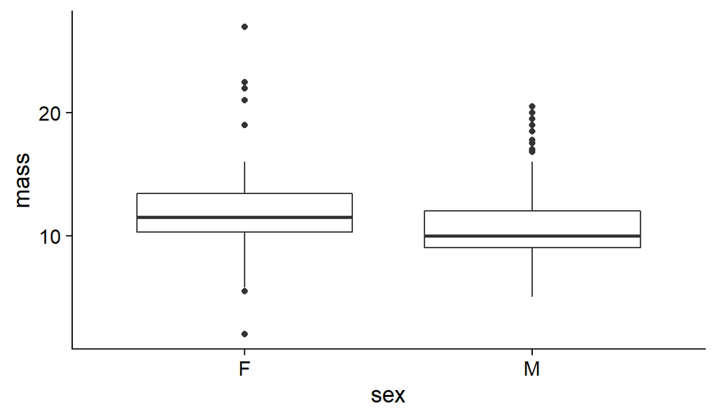

```r
ggplot(data = bats, aes(x = sex, y = mass))+
  geom_boxplot()
```

## Raw data as an alternative to boxplots

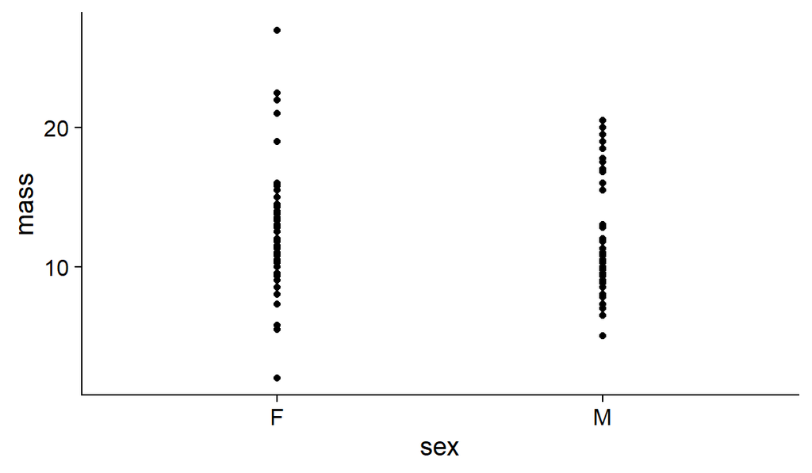

```r
ggplot(bats, aes(x = sex, y = mass))+
  geom_point()
```

## Raw data as an alternative to boxplots

Add a little jitter and transparency on the x axis to keep from overplotting.

```r
ggplot(bats, aes(x = sex, y = mass))+
  geom_point(position = position_jitter(width = 0.3), alpha = 0.5)
```

## Raw data as an alternative to boxplots

Add a little jitter and transparency on the x axis to keep from overplotting.

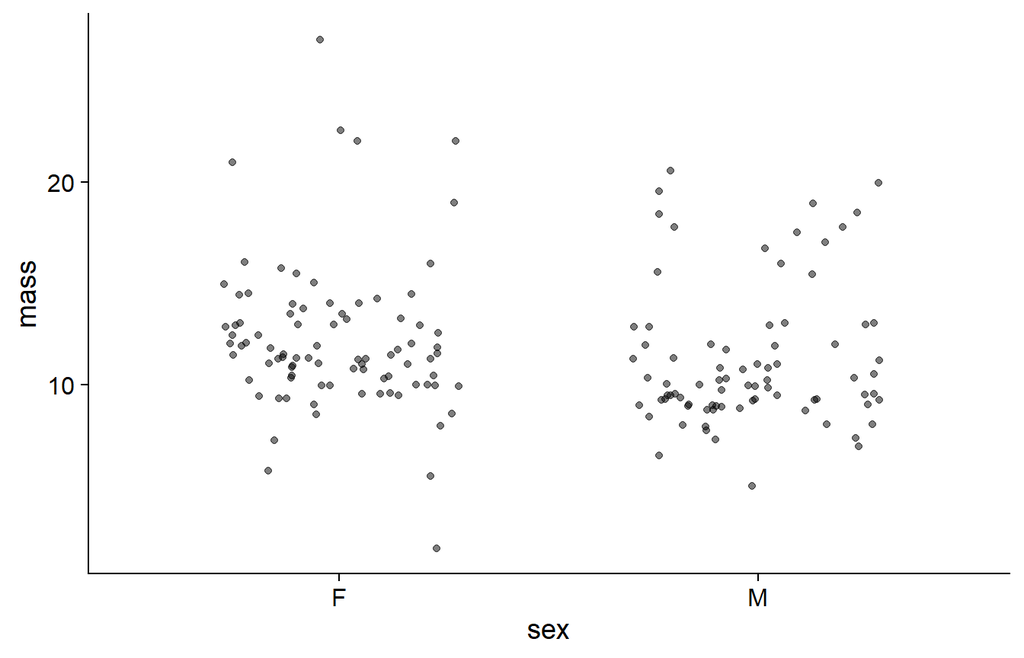

## Boxplots and raw data

```r
ggplot(bats, aes(x = sex, y = mass))+
  geom_boxplot()+
  geom_point(position = position_jitter(width = 0.3), alpha = 0.5,
             color = "blue")
```

## Boxplots and raw data

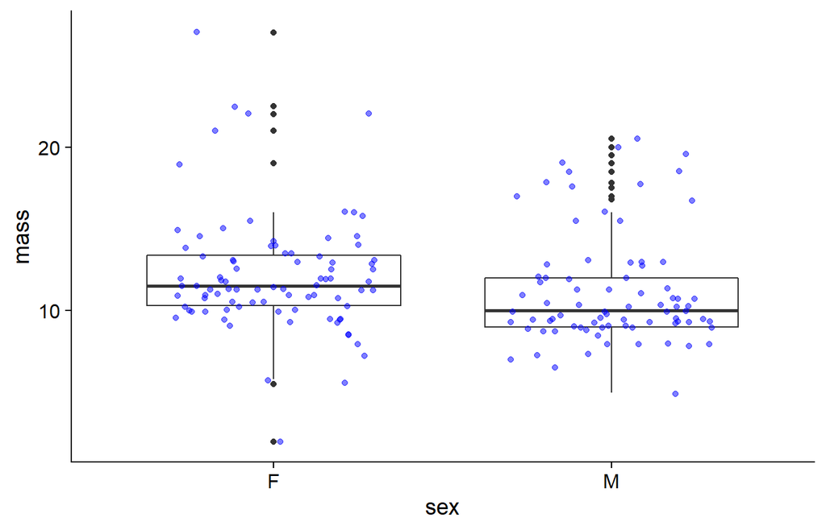

## Boxplots and raw data

You can “bring the boxplot to the front” by switching the order of `geom_point()` and `geom_boxplot()`.

```r
ggplot(bats, aes(x = sex, y = mass))+
  geom_point(position = position_jitter(width = 0.3), alpha = 0.5,
             color = "blue")+
  geom_boxplot(alpha = 2/3)
```

## Boxplots and raw data

You can “bring the boxplot to the front” by switching the order of `geom_point()` and `geom_boxplot()`.

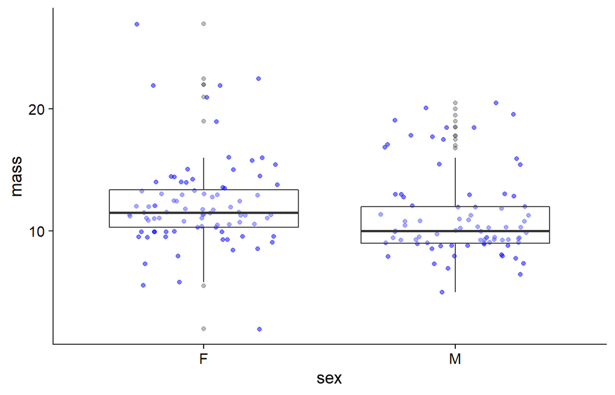

## Boxplots and coord flips

You can also pick a different variable to group by and flip your axes.

```r
ggplot(bats, aes(x = condition, y = RFA))+
  geom_boxplot()+
  geom_point(position = position_jitter(width = 0.3), alpha = 0.5,
             color = "blue")+
  coord_flip()
```

## Boxplots and coord flips

You can also pick a different variable to group by and flip your axes.

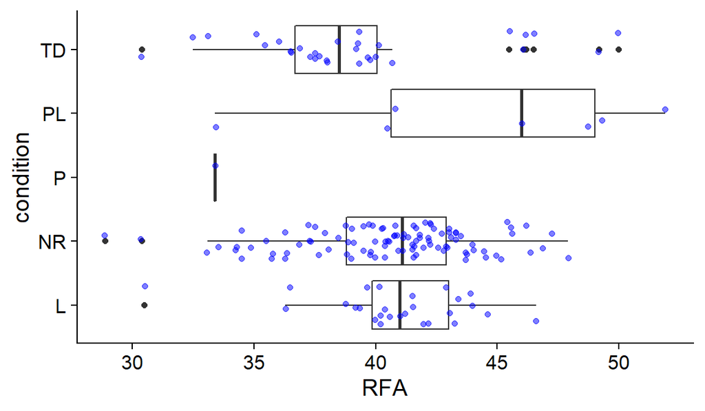

## Boxplots Re-ordered

Sometimes you want your groups in a specific order, not alphabetical

```r
bats$condition<-factor(bats$condition, levels =
                        c("L", "P","PL", "TD", "NR"))

ggplot(bats, aes(x = condition, y = RFA))+
  geom_boxplot()+
  geom_point(position = position_jitter(width = 0.3), alpha = 0.5,
             color = "blue")+
  coord_flip()
```

## Boxplots Re-ordered

Sometimes you want your groups in a specific order, not alphabetical

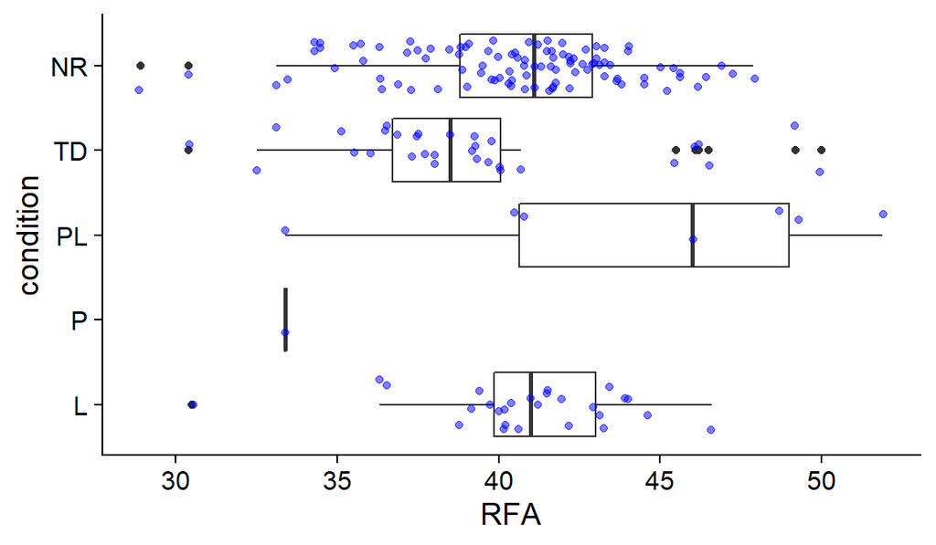

## Look at Your Data - Distributions

`geom_histogram()` - allows you to see the distribution of your data

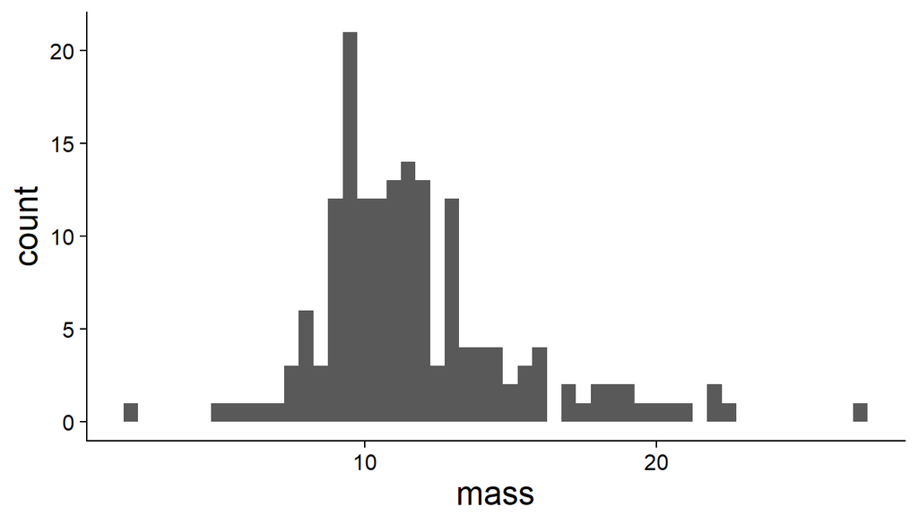

```r
ggplot(bats)+
  geom_histogram(aes(x = mass), binwidth=.5)+
  theme(text = element_text(size=18))
```

## Look at Your Data - Distributions

`geom_freqpoly()` - same calculations as `geom_histogram()` but displays as lines instead of bars.

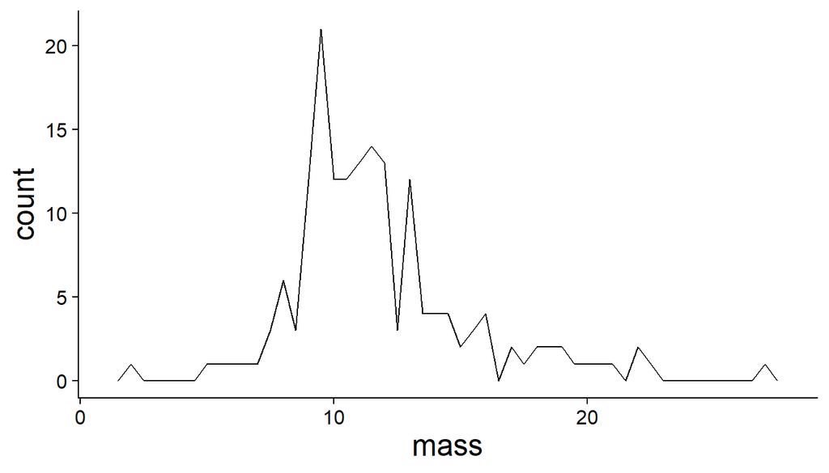

```r
ggplot(bats)+
  geom_freqpoly(aes(x = mass), binwidth = 0.5)+
  theme(text = element_text(size=18))
```

## Look at Your Data - Distributions

`geom_freqpoly()` - helpful if you want to look at multiple distributions at once.

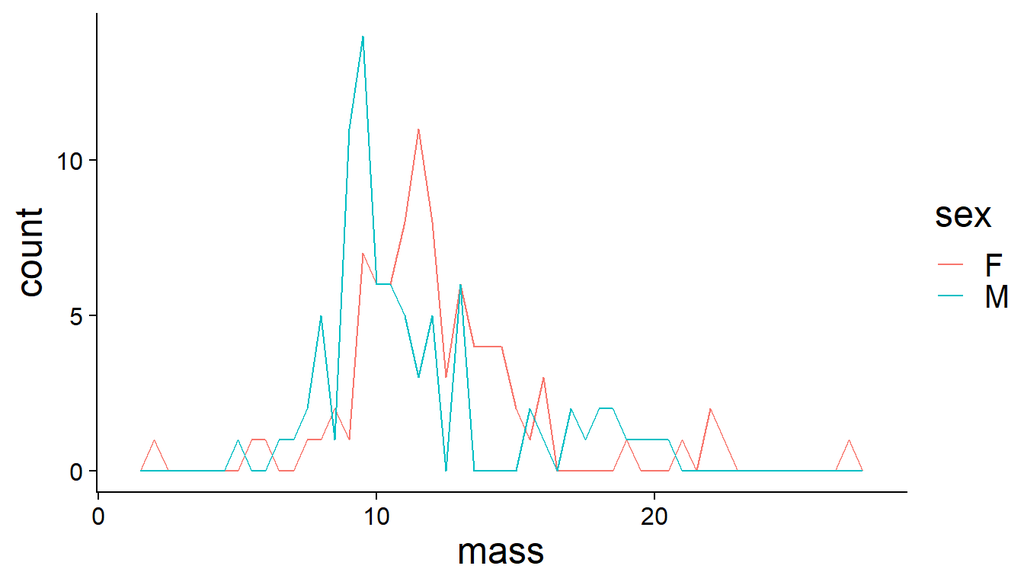

```r
ggplot(bats)+
  geom_freqpoly(aes(x = mass, color = sex), binwidth = 0.5)+
  theme(text = element_text(size=18))
```

## Look at Your Data - Distributions

`geom_density()` - normalizes your data instead of counts.

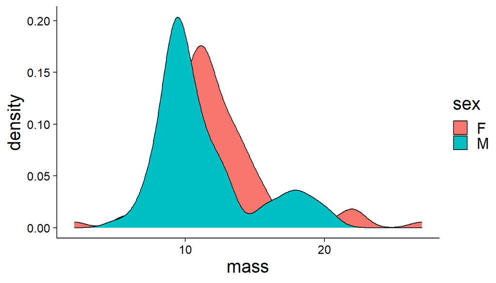

```r
ggplot(bats)+
  geom_density(aes(x = mass, fill = sex))+
  theme(text = element_text(size=18))
```

## Look at Your Data - Distributions

Let’s check the moonlight data

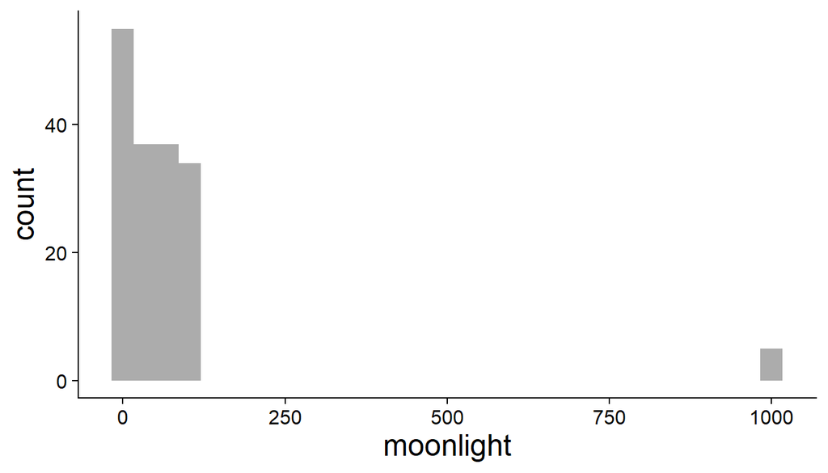

```r
ggplot(bats)+
  geom_histogram(aes(x = moonlight), alpha = 0.5)+
  theme(text = element_text(size=18))
```

## Finding suspect observations

```r
bats %>%
  select(bat_ID, age, mass, moonlight) %>%
  arrange(moonlight)
```

```
## # A tibble: 168 x 4
##    bat_ID age    mass moonlight
##     <dbl> <chr> <dbl>     <dbl>
##  1    107 J       9.3         0
##  2    108 J       7.8         0
##  3    109 J      11.5         0
##  4    110 J      15.5         0
##  5    111 A      15.5         0
##  6    112 J       9.8         0
##  7    113 J      10           0
##  8    114 J       7.3         2
##  9    115 J      10           2
## 10    116 J       9.3         2
## # ... with 158 more rows
```

## Finding suspect observations

```r
bats %>%
  select(bat_ID, age, mass, moonlight) %>%
  arrange(desc(moonlight))
```

```
## # A tibble: 168 x 4
##    bat_ID age    mass moonlight
##     <dbl> <chr> <dbl>     <dbl>
##  1     40 A      15        1000
##  2     41 J       9        1000
##  3     42 J      11        1000
##  4      1 A       5         990
##  5    155 J      12.5       990
##  6    148 J      11.3        99
##  7    149 A       7.3        99
##  8    150 J       8.8        99
##  9    151 J       5.8        99
## 10    152 J      13          99
## # ... with 158 more rows
```

## What to do?

1. Are the observations really incorrect?
   - Malfunction
2. Was there a data entry error?
   - Check the original data sheets

## Filter

```r
bats_filt <- bats %>%
  filter(moonlight < 100)

max(bats_filt$moonlight)
```

```
## [1] 99
```

## Replace values

```r
bats$moonlight[bats$moonlight == 1000] <- 100

bats$moonlight[bats$moonlight == 990 &
                  bats$bat_ID == 155] <- 99

bats$moonlight[bats$moonlight == 990 &
                  bats$bat_ID == 1] <- 0
```

## Doublecheck your fixes

```r
bats %>%
  select(bat_ID, age, mass, moonlight) %>%
  arrange(moonlight)
```

```
## # A tibble: 168 x 4
##    bat_ID age    mass moonlight
##     <dbl> <chr> <dbl>     <dbl>
##  1      1 A       5           0
##  2    107 J       9.3         0
##  3    108 J       7.8         0
##  4    109 J      11.5         0
##  5    110 J      15.5         0
##  6    111 A      15.5         0
##  7    112 J       9.8         0
##  8    113 J      10           0
##  9    114 J       7.3         2
## 10    115 J      10           2
## # ... with 158 more rows
```

## Doublecheck your fixes

```r
bats %>%
  select(bat_ID, age, mass, moonlight) %>%
  arrange(desc(moonlight)) %>%
  print(n = 11)
```

```
## # A tibble: 168 x 4
##    bat_ID age    mass moonlight
##     <dbl> <chr> <dbl>     <dbl>
##  1     40 A      15         100
##  2     41 J       9         100
##  3     42 J      11         100
##  4    148 J      11.3        99
##  5    149 A       7.3        99
##  6    150 J       8.8        99
##  7    151 J       5.8        99
##  8    152 J      13          99
##  9    153 J       9.3        99
## 10    154 J      10          99
## 11    155 J      12.5        99
## # ... with 157 more rows
```

## Doublecheck your fixes

Let’s re-check the moonlight data

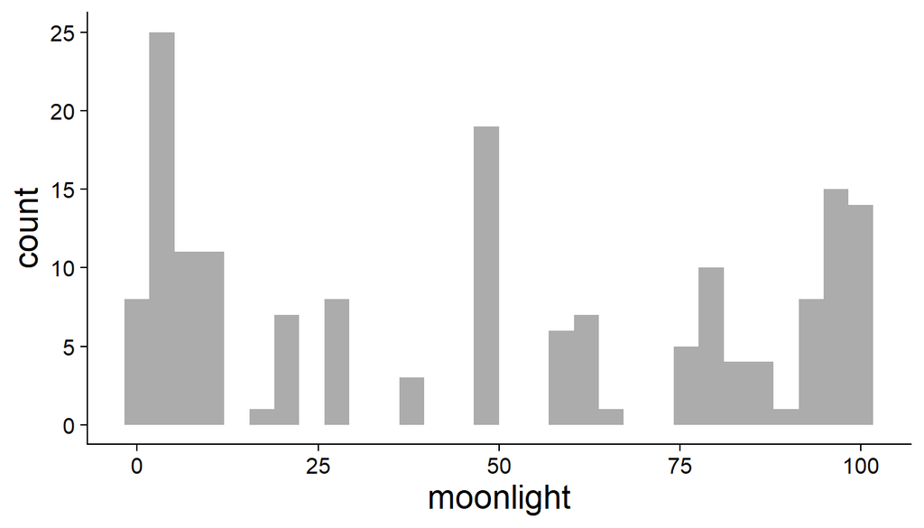

```r
ggplot(bats)+
  geom_histogram(aes(x = moonlight), alpha = 0.5)+
  theme(text = element_text(size=18))
```